# Story 2 - The Feds Dual Mandate

Keith Colella

2024-02-18

```r
library(tidyverse)
library(fredr)
library(blsAPI)
library(jsonlite)
library(lubridate)
library(zoo)
```

Read in API keys

```r
keys <- fromJSON('data/api_keys.json')
```

## Data

BLS API: https://www.bls.gov/developers/home.htm

```r
# https://www.bls.gov/cpi/overview.htm

year_ranges <- list(c('2005','2024'), c('1985','2005'))

cpi <- data.frame()
ue <- data.frame()

for (year_range in year_ranges){
  request <- list(
    'seriesid' = c('CUUR0000SA0L1E', 'LNS14000000'),
    'startyear' = year_range[1], 'endyear' = year_range[2],
    'registrationkey' = keys$bls
  )

  response <- blsAPI(request)
  json <- fromJSON(response)

  df1 <- json$Results$series$data[[1]]
  cpi <- rbind(cpi, df1[c('year', 'period', 'value')])

  df2 <- json$Results$series$data[[2]]
  ue <- rbind(ue, df2[c('year', 'period', 'value')])
}

cpi <- cpi %>%
  mutate(
    month = as.numeric(str_remove(period, 'M')),
    year = as.numeric(year),
    value = as.numeric(value)
  )

ue <- ue %>%
  mutate(
    month = as.numeric(str_remove(period, 'M')),
    year = as.numeric(year),
    value = as.numeric(value)
  )
```

FRED API: https://www.rdocumentation.org/packages/fredr/versions/2.1.0

```r
fredr_set_key(keys$fred)

fed_funds <- fredr(
  series_id = 'FEDFUNDS',
  observation_start = as.Date('1985-01-01'),
  observation_end = as.Date('2024-02-01')
)

fed_funds <- fed_funds %>%
  mutate(
    year = year(date),
    month = month(date)
  )

fed_target <- fredr(
  series_id = 'DFEDTARU',
  observation_start = as.Date('1985-01-01'),
  observation_end = as.Date('2024-02-01')
)

fed_target <- fed_target %>%
  mutate(
    year = year(date),
    month = month(date)
  )

recession <- fredr(
  series_id = 'JHDUSRGDPBR',
  observation_start = as.Date('1985-01-01'),
  observation_end = as.Date('2024-02-01')
)

recession <- recession %>%
  mutate(
    year = year(date),
    month = month(date)
  )

recession_dates <- recession %>%
  mutate(recession_start = value == 1 & lag(value) == 0,
         recession_end = value == 1 & lead(value) == 0) %>%
  replace_na(list(recession_start = TRUE)) %>%
  filter(recession_start | recession_end) %>%
  mutate(period_id = cumsum(recession_start)) %>%
  group_by(period_id) %>%
  summarise(start = min(date), end = max(date)) %>%
  ungroup()
```

Merge and create new columns

```r
df <- left_join(cpi, ue, by = c('year', 'month')) %>%
  left_join(fed_funds, by = c('year', 'month')) %>%
  left_join(fed_target, by = 'date') %>%
  rename(
    cpi = value.x, ue = value.y,
    fed_funds = value.x.x, fed_target = value.y.y
  ) %>%
  select(date, cpi, ue, fed_funds, fed_target) %>%
  arrange(date) %>%
  mutate(
    fed_target = if_else(is.na(fed_target), ceiling(fed_funds * 4) / 4, fed_target),
    cpi_growth = (cpi/lag(cpi, n = 12) - 1) * 100
  )

head(df)
```

```
##         date   cpi  ue fed_funds fed_target cpi_growth
## 1 1985-01-01 106.9 7.3      8.35       8.50         NA
## 2 1985-02-01 107.4 7.2      8.50       8.50         NA
## 3 1985-03-01 107.9 7.2      8.58       8.75         NA
## 4 1985-04-01 108.2 7.3      8.27       8.50         NA
## 5 1985-05-01 108.6 7.2      7.97       8.00         NA
## 6 1985-06-01 108.8 7.4      7.53       7.75         NA
```

## Visualizations

Levels

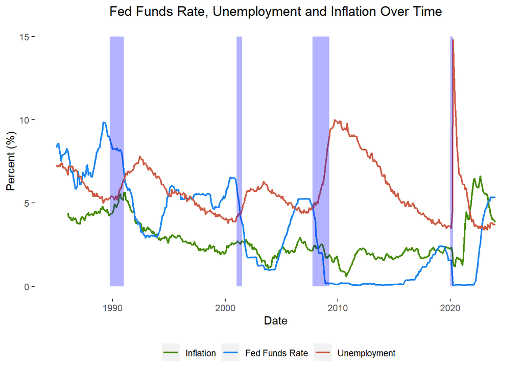

```r
df %>%
  pivot_longer(cols = c(cpi_growth, ue, fed_funds)) %>%
  ggplot(aes(date, value, color = name)) +
  geom_line(size = 0.8) +
  geom_rect(
    data = recession_dates,
    aes(xmin = start, xmax = end, ymin = 0, ymax = 15),
    fill = 'blue', alpha = 0.3, inherit.aes = FALSE
  ) +
  ggtitle('Fed Funds Rate, Unemployment and Inflation Over Time') +
  xlab('Date') +
  ylab('Percent (%)') +
  scale_color_manual(
    values = c('cpi_growth' = 'chartreuse4', 'fed_funds' = 'dodgerblue2', 'ue' = 'coral3'),
    name = '',
    labels = c('cpi_growth' = 'Inflation', 'fed_funds' = 'Fed Funds Rate', 'ue' = 'Unemployment')
  ) +
  theme(
    plot.title = element_text(hjust = 0.5),
    legend.position = 'bottom',
    panel.background = element_blank()
  )
```

Identify Rate & Hike Cycles

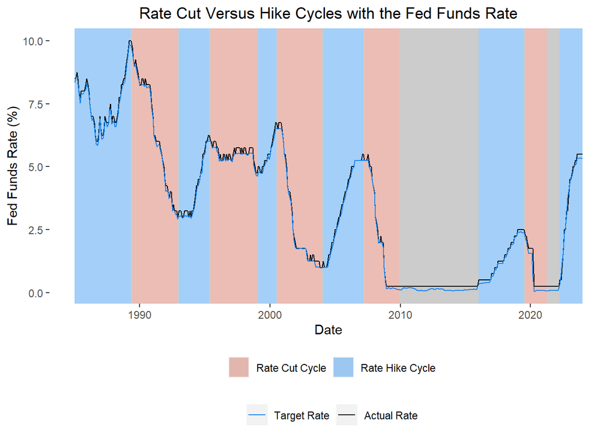

```r
df <- df %>%
  mutate(
    fed_roll_peak = rollapply(
      fed_target, width = 52, FUN = max,
      align = 'center', fill = c(NA, NA, 'extend')
    ),
    fed_roll_valley = rollapply(
      fed_target, width = 52, FUN = min,
      align = 'center', fill = c(NA, NA, 'extend')
    ),
    fed_status = case_when(
      fed_target == fed_roll_peak & fed_target > lead(fed_target) ~ 'peak',
      fed_target == fed_roll_valley & fed_target < lead(fed_target)~ 'valley',
      .default = 'between'
    )) %>%
  select(-fed_roll_peak, -fed_roll_valley)

previous_cycle <- 'hike'
current_cycle <- 'hike'

for (row in 1:nrow(df)) {
  if (df[row, 'fed_status'] == 'peak') {current_cycle <- 'cut'}
  if (df[row, 'fed_status'] == 'valley') {current_cycle <- 'hike'}

  lags <- c(df[row, 'fed_target'])

  for (lag in 1:12) {
    lags <- c(lags, df[row-lag, 'fed_target'])
  }

  if (all(diff(lags) == 0)) {
    df[row, 'fed_status'] <- 'maintain'
  } else if (current_cycle == 'cut' & previous_cycle != 'cut') {
    df[row, 'fed_status'] <- 'start_cut'
  } else if (current_cycle == 'hike' & previous_cycle != 'hike') {
    df[row, 'fed_status'] <- 'start_hike'
  } else if (current_cycle == 'cut' & previous_cycle == 'cut') {
    df[row, 'fed_status'] <- 'cut'
  } else if (current_cycle == 'hike' & previous_cycle == 'hike') {
    df[row, 'fed_status'] <- 'hike'
  }

  previous_cycle <- current_cycle
}

df[nrow(df), 'fed_status'] <- 'cut'

ggplot() +
  geom_rect(data = df, aes(
    xmin = date, xmax = lead(date, order_by = date),
    ymin = -Inf, ymax = Inf, fill = fed_status
  ), alpha = 0.4) +
  geom_line(data = df, aes(x = date, y = fed_target, color = 'Target Rate')) +
  geom_line(data = df, aes(x = date, y = fed_funds, color = 'Actual Rate')) +
  ggtitle('Rate Cut Versus Hike Cycles with the Fed Funds Rate') +
  xlab('Date') +
  ylab('Fed Funds Rate (%)') +
  scale_fill_manual(
    values = c('cut' = 'coral3', 'hike' = 'dodgerblue2'),
    name = '',
    labels = c('cut' = 'Rate Cut Cycle', 'hike' = 'Rate Hike Cycle')
  ) +
  scale_color_manual(
    values = c('Target Rate' = 'black', 'Actual Rate' = 'dodgerblue2'),
    name = '',
    labels = c('Target Rate', 'Actual Rate')
  ) +
  theme(
    plot.title = element_text(hjust = 0.5),
    legend.position = 'bottom', legend.box = 'vertical',
    panel.background = element_blank()
  )
```

Fine Tune Dates and Set up Cycle DFs

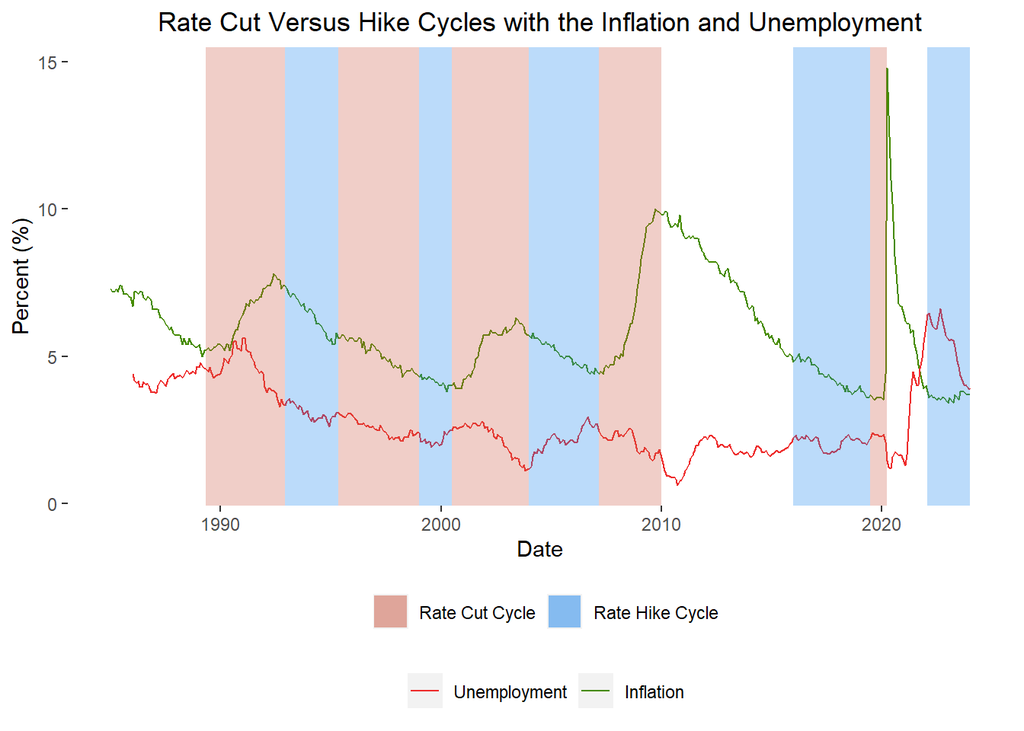

```r
cut_cycles <- data.frame(
  start = as.Date(c('1989-05-01','1995-05-01','2000-07-01','2007-03-01','2019-07-01')),
  end = as.Date(c('1992-12-01','1999-01-01','2004-01-01','2010-01-01','2020-04-01'))
)

hike_cycles <- data.frame(
  start = as.Date(c('1992-12-01','1999-01-01','2004-01-01','2016-01-01','2022-02-01')),
  end = as.Date(c('1995-05-01','2000-07-01','2007-03-01','2019-07-01','2024-01-01'))
)

ggplot() +
  geom_line(data = df, aes(x = date, y = ue, color = 'Unemployment')) +
  geom_line(data = df, aes(x = date, y = cpi_growth, color = 'Inflation')) +
  geom_rect(
    data = cut_cycles, aes(
      xmin = start, xmax = end, ymin = -Inf, ymax = Inf, fill = 'Rate Cut Cycle'
      ), alpha = 0.3, inherit.aes = FALSE
  ) +
  geom_rect(
    data = hike_cycles, aes(
      xmin = start, xmax = end, ymin = -Inf, ymax = Inf, fill = 'Rate Hike Cycle'
    ), alpha = 0.3, inherit.aes = FALSE
  ) +
  ggtitle('Rate Cut Versus Hike Cycles with the Inflation and Unemployment') +
  xlab('Date') +
  ylab('Percent (%)') +
  scale_fill_manual(
    values = c('Rate Cut Cycle' = 'coral3', 'Rate Hike Cycle' = 'dodgerblue2'),
    name = '',
    labels = c('Rate Cut Cycle', 'Rate Hike Cycle')
  ) +
  scale_color_manual(
    values = c('Unemployment' = 'chartreuse4', 'Inflation' = 'firebrick2'),
    name = '',
    labels = c('Unemployment', 'Inflation')
  ) +
  theme(
    plot.title = element_text(hjust = 0.5),
    legend.position = 'bottom', legend.box = 'vertical',
    panel.background = element_blank()
  )
```

Calculate changes in UE and CPI after each cycle

```r
for (row in 1:nrow(cut_cycles)) {

  time_to_change <- as.period(hike_cycles[row, 2] - cut_cycles[row, 2])
  obs_period <- if_else(time_to_change < months(60), time_to_change, months(60))

  cut_cycles[row, 'obs_period_end'] <- cut_cycles[row, 2] + obs_period

  cut_cycles[row, 'ff_change'] <-
    df[df$date == cut_cycles[row, 2], 'fed_funds'] -
    df[df$date == cut_cycles[row, 1], 'fed_funds']

  cut_cycles[row, 'infl_change'] <-
    df[df$date == cut_cycles[row, 2] + obs_period, 'cpi_growth'] -
    df[df$date == cut_cycles[row, 2], 'cpi_growth']

  cut_cycles[row, 'ue_change'] <-
    df[df$date == cut_cycles[row, 2] + obs_period, 'ue'] -
    df[df$date == cut_cycles[row, 2], 'ue']
}

for (row in 1:nrow(hike_cycles)) {

  if (row == nrow(hike_cycles)) {
    obs_period <- 0
    adjustment <- 1
  } else {
    time_to_change <- as.period(cut_cycles[row+1, 2] - hike_cycles[row, 2])
    obs_period <- if_else(time_to_change < months(60), time_to_change, months(60))
    adjustment <- 0
  }

  hike_cycles[row, 'obs_period_end'] <- hike_cycles[row, 2] + obs_period

  hike_cycles[row, 'ff_change'] <-
    df[df$date == hike_cycles[row, 2], 'fed_funds'] -
    df[df$date == hike_cycles[row, 1], 'fed_funds']

  hike_cycles[row, 'infl_change'] <-
    df[df$date == hike_cycles[row, 2] + obs_period, 'cpi_growth'] -
    df[df$date == hike_cycles[row, 2 - adjustment], 'cpi_growth']

  hike_cycles[row, 'ue_change'] <-
    df[df$date == hike_cycles[row, 2] + obs_period, 'ue'] -
    df[df$date == hike_cycles[row, 2 - adjustment], 'ue']
}

cut_cycles <- cut_cycles %>%
  mutate(label = str_c(
    'Cut Cycle: ', format(start, "%b-%y"),
    ' – ', format(end, "%b-%y"),
    ' / Observation Period: ', format(end, "%b-%y"),
    ' – ', format(obs_period_end, "%b-%y")
  ))

hike_cycles <- hike_cycles %>%
  mutate(label = str_c(
    'Hike Cycle: ', format(start, "%b-%y"),
    ' – ', format(end, "%b-%y"),
    ' / Observation Period: ', format(end, "%b-%y"),
    ' – ', format(obs_period_end, "%b-%y")
  ))

hike_cycles[5,7] <- 'Hike Cycle: Feb-22 – Jan-24 / Observation Period: Feb-22 – Jan-24'

cut_cycles
```

```
##        start        end obs_period_end ff_change infl_change ue_change
## 1 1989-05-01 1992-12-01     1995-05-01     -6.89 -0.24717665      -1.8
## 2 1995-05-01 1999-01-01     2000-07-01     -1.38  0.09242114      -0.3
## 3 2000-07-01 2004-01-01     2007-03-01     -5.54  1.30441157      -1.3
## 4 2007-03-01 2010-01-01     2015-01-01     -5.15  0.09528951      -4.1
## 5 2019-07-01 2020-04-01     2024-01-01     -2.35  2.42958952     -11.1
##                                                              label
## 1 Cut Cycle: May-89 – Dec-92 / Observation Period: Dec-92 – May-95
## 2 Cut Cycle: May-95 – Jan-99 / Observation Period: Jan-99 – Jul-00
## 3 Cut Cycle: Jul-00 – Jan-04 / Observation Period: Jan-04 – Mar-07
## 4 Cut Cycle: Mar-07 – Jan-10 / Observation Period: Jan-10 – Jan-15
## 5 Cut Cycle: Jul-19 – Apr-20 / Observation Period: Apr-20 – Jan-24
```

```r
hike_cycles
```

```
##        start        end obs_period_end ff_change infl_change ue_change
## 1 1992-12-01 1995-05-01     1999-01-01      3.09  -0.6820633      -1.3
## 2 1999-01-01 2000-07-01     2004-01-01      1.91  -1.3402528       1.7
## 3 2004-01-01 2007-03-01     2010-01-01      4.26  -0.8978150       5.4
## 4 2016-01-01 2019-07-01     2020-04-01      2.06  -0.7778993      11.1
## 5 2022-02-01 2024-01-01     2024-01-01      5.25  -2.5524621      -0.1
##                                                               label
## 1 Hike Cycle: Dec-92 – May-95 / Observation Period: May-95 – Jan-99
## 2 Hike Cycle: Jan-99 – Jul-00 / Observation Period: Jul-00 – Jan-04
## 3 Hike Cycle: Jan-04 – Mar-07 / Observation Period: Mar-07 – Jan-10
## 4 Hike Cycle: Jan-16 – Jul-19 / Observation Period: Jul-19 – Apr-20
## 5 Hike Cycle: Feb-22 – Jan-24 / Observation Period: Feb-22 – Jan-24
```

Plot separate Bar Charts

[figure not shown]

```r
cut_plot <- cut_cycles %>%
  pivot_longer(cols = c(ff_change, ue_change)) %>%
  mutate(
    end = as.character(year(end)),
    value = (value)
  ) %>%
  ggplot(aes(end, value, fill = name)) +
  geom_col(position = position_dodge()) +
  ggtitle('Fed Funds Rate Hikes and Resulting Changes in Unemployment') +
  xlab(NULL) +
  ylab('Change (%)') +
  scale_fill_manual(
    values = c('ff_change' = 'dodgerblue2', 'ue_change' = 'firebrick2'),
    name = NULL,
    labels = c('ff_change' = 'Change in Fed Funds Rate', 'ue_change' = 'Change in Unemployment')
  ) +
  theme(
    plot.title = element_text(hjust = 0.5),
    panel.background = element_blank(),
    legend.position = 'bottom', legend.box = 'vertical',
    axis.ticks.x = element_blank()
  )

hike_plot <- hike_cycles %>%
  mutate(
    end = as.character(year(end)),
    infl_change = (infl_change)
  ) %>%
  pivot_longer(cols = c(ff_change, infl_change)) %>%
  ggplot(aes(end, value, fill = name)) +
  geom_col(position = position_dodge()) +
  ggtitle('Fed Funds Rate Hikes and Resulting Changes in Inflation') +
  xlab(NULL) +
  ylab('Change (%)') +
  scale_fill_manual(
    values = c('ff_change' = 'dodgerblue2', 'infl_change' = 'chartreuse4'),
    name = NULL,
    labels = c('ff_change' = 'Change in Fed Funds Rate', 'infl_change' = 'Change in Inflation')
  ) +
  theme(
    plot.title = element_text(hjust = 0.5),
    panel.background = element_blank(),
    legend.position = 'bottom', legend.box = 'vertical',
    axis.ticks.x = element_blank()
  )

cut_plot
```

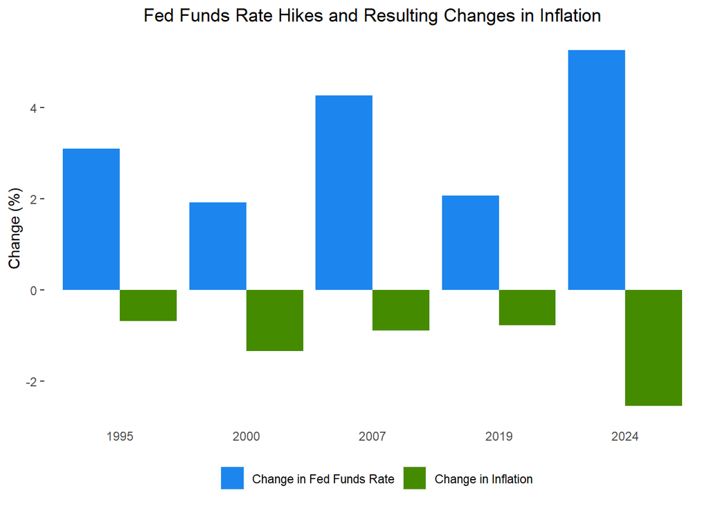

```r
hike_plot
```

# Final Plot

This final plots shows that the Fed typically succeeds in its dual mandate. After each cut cycle, we typically see unemployment decrease. After each hike cycle, we typically see inflation decrease. This plot, however, also shows that contradictory nature of the dual mandate. After many cut cycles, we see some increase in inflation, and after many hike cycles, we see some increase in unemployment. Historical context is important here, as sometimes the Fed may intend to drive up some unemployment to “cool” the economy. Similarly, it may sometimes intend to increase inflation during periods of high disinflation. Regardless, this plot helps us determine that cuts typically drive higher employment and hikes typically drive lower inflation.

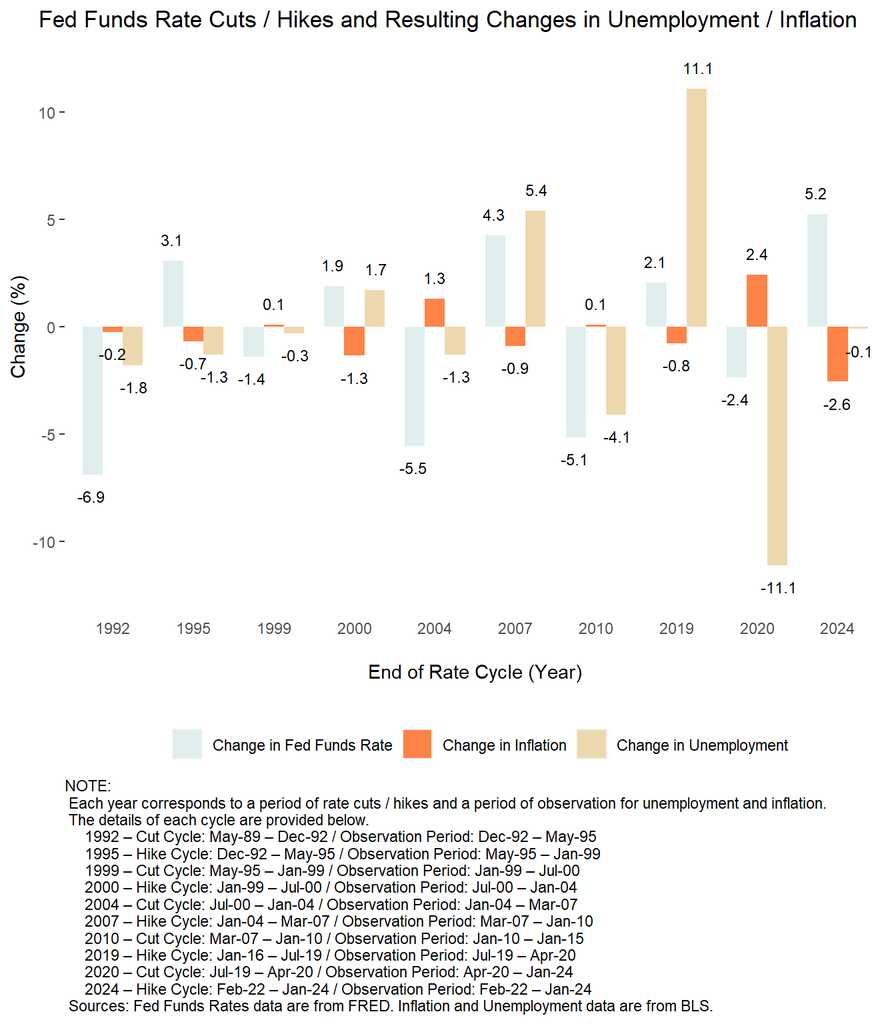

```r
caption <- str_c(
  'NOTE:',
  '\n Each year corresponds to a period of rate cuts / hikes and a period of observation for unemployment and inflation.',
  '\n The details of each cycle are provided below.'
)

for (row in 1:nrow(cut_cycles)) {
  cut_caption <- str_c(year(cut_cycles[row, 'end']), ' – ', cut_cycles[row, 'label'])
  caption <- str_c(caption, '\n     ', cut_caption)

  hike_caption <- str_c(year(hike_cycles[row, 'end']), ' – ', hike_cycles[row, 'label'])
  caption <- str_c(caption, '\n     ', hike_caption)
}

caption <- str_c(caption, '\n Sources: Fed Funds Rates data are from FRED. Inflation and Unemployment data are from BLS.')

final_plot <- rbind(cut_cycles, hike_cycles) %>%
  pivot_longer(cols = c(ff_change, ue_change, infl_change)) %>%
  filter(!is.na(value)) %>%
  mutate(label = fct_reorder(label, end), end = as.character(year(end))) %>%
  arrange(end) %>%
  ggplot(aes(x = end, y = value, fill = name)) +
  geom_col(position = position_dodge(), width = 0.75) +
  labs(
    x = 'End of Rate Cycle (Year)', y = 'Change (%)',
    title = 'Fed Funds Rate Cuts / Hikes and Resulting Changes in Unemployment / Inflation',
    caption = caption
  ) +
  scale_fill_manual(
    values = c(
      'ff_change' = 'azure2',
      'ue_change' = 'wheat2',
      'infl_change' = 'sienna1'
    ),
    labels = c(
      'ff_change' = 'Change in Fed Funds Rate',
      'ue_change' = 'Change in Unemployment',
      'infl_change' = 'Change in Inflation'
    ),
    name = NULL,
  ) +
  scale_x_discrete(position = 'bottom') +
  geom_text(
    aes(label = round(value,1), y = ifelse(value > 0, value + 1, value - 1)),
    position = position_dodge(0.8),
    color = "black", size = 3.2
  ) +
  theme(
    plot.title.position = 'plot',
    plot.title = element_text(hjust = 0.5),
    plot.caption = element_text(hjust = 0),
    panel.background = element_blank(),
    legend.position = 'bottom', legend.box = 'vertical',
    axis.ticks.x = element_blank(),
    axis.title.x = element_text(margin = margin(t = 15, b = 10))
  )

final_plot
```

```r
ggsave('story2_KeithC_finalPlot.png', plot = final_plot, width = 7, height = 8, dpi = 500)
```